# MATH 141

## Example from last time

How many quizzes should we have printed in total for MATH 141 today?

- The Registrar at Reed has told us that students tend to come to class about 93% of the time
- There are 38 students registered in total
- What specific assumptions are required for us to assume a Binomial/Independent Trials model?
  - Students come to class *independently* of one another
  - Each student has a 93% chance of attending class today
  - Students either come to class or they don't
- What does this distribution look like?
  - http://ismay.shinyapps.io/ProbApp

## Poisson Distribution

### How *weird* are Obama's three Supreme Court Justice nominations?

\(X\) - The number of Justice nominations for US two (full) term Presidents can be modeled using a Poisson Distribution (\(X \sim Pois(\lambda = 3.54)\))

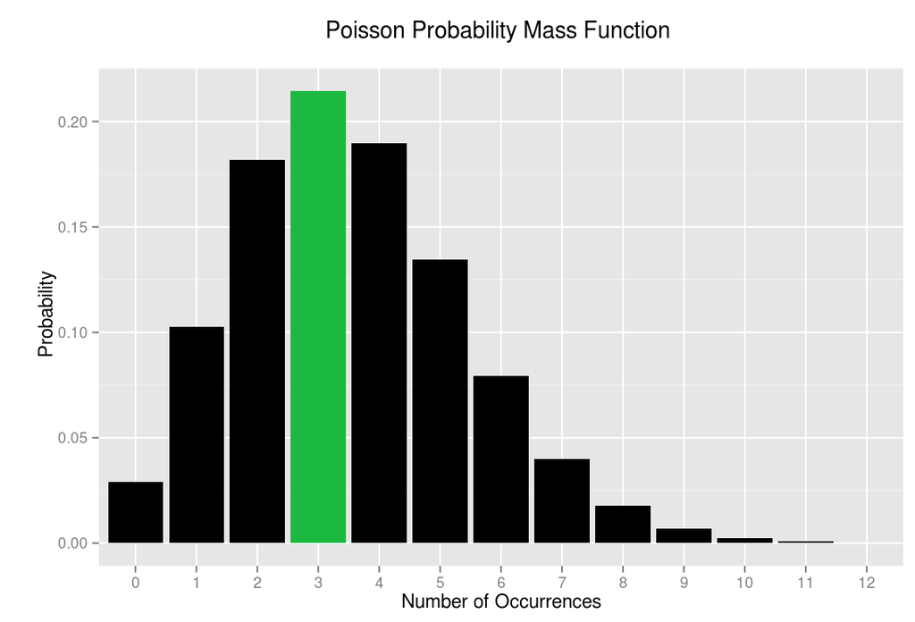

## So what's a Poisson distribution?

- Originated in an attempt to find a simple approximation for binomial probabilities in situations where
  - there are a large number of independent trials
  - each with a small probability of success
- It is a probability model for **rare events**
- Other examples:
  - \(C\) = The count of salamanders found in a 10 meter square region of the Reed canyon during a 1 hour period
  - \(P\) = The number of incoming phone calls at the Reed switchboard in a 10 minute period